# Summary Fourier Transform (DFT, STFT)

Erick David Rodriguez-Orduna

Based on Notes from Wavelet Graduate Course from [Dr Vicente Alarcon](https://sites.google.com/site/vicentevialaq/)

It also includes more experiments with different Signals and Plots

Return to Website here

[Twitter](https://twitter.com/ErickRodOrd)

```matlab
clear;
```

Table of Contents:

Generating a Sample Signal with Varying Frequency Example 1: Manual Spans, Manual Frequencies Example 2: Same Span, Manual Freqs Fourier Transform (FFT) and Short Time Fourier Transform The Folding Appendices Appendix A - Folding

## Generating a Sample Signal with Varying Frequency

### Example 1: Manual Spans, Manual Frequencies

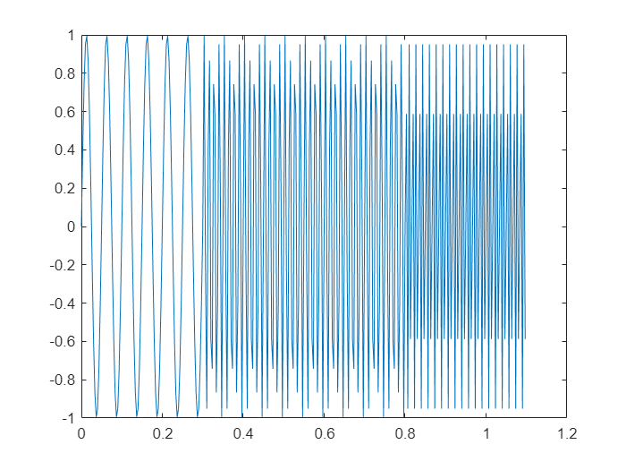

```matlab
clear;
Frecuencies = [20,80,120]; %Choose your own Frequencies
Spans = [0.3,0.5,0.3]; %Choose the Span of the Freqs in Secs
fs = max(Frecuencies)*2.5; %Select a Frequency Sample of 2.5 times the max frequency (Above Nyquist Theorem)
F =[]; % Generate a List for the Signal
iter = 1; %Iterate Through Spans
for freq = Frecuencies
    F = [F,repelem(freq,Spans(iter)*fs)]; %Generate an array of frequencies and repeat N times depending on Span.
    iter = iter + 1;
end
dt = 1/fs;  %Generate Delta for signal sampling
StopTime = length(F)/fs; %Length of Signal (Sum of Spans)
t = (0:dt:StopTime-dt);  %generate Array of times
amp = 1; %Amplitude of the Signal


for i= 1:length(t)
    signal(i) = amp*sin(2*pi*F(i)*t(i)); %Generate Sinusoid
end;

figure() %generate a figure Avoid figures in cache
plot(t,signal)
```

### Example 2: Same Span, Manual Freqs

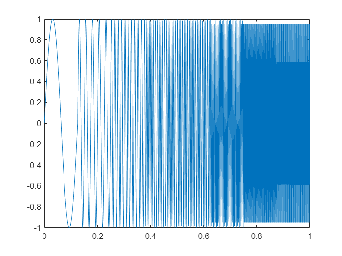

```matlab
clear;
Frecuencies = [1,5,10,15,20,30,50,100];
fs = max(Frecuencies)*2.5;
F = [];
for freq = Frecuencies
    F = [F,repelem(freq,fs)]; %Frequency Array
end

dt = 1/fs;  %Generate Delta for signal sampling
StopTime = length(F)/fs; %Length of Signal (Sum of Spans)
t = (0:dt:StopTime-dt);  %generate Array of times
amp = 1; %Amplitude of the Signal


for i= 1:length(t)
    signal(i) = amp*sin(2*pi*F(i)*t(i)); %Generate Sinusoid
end;

figure() %generate a figure Avoid figures in cache
plot(t/length(Frecuencies),signal)
```

## Fourier Transform (FFT) and Short Time Fourier Transform

#### The Folding

will happen when the Sampling Frecuency is not at least 2 times larger than the maximum frecuency (Or the desired Frequency within the signal)

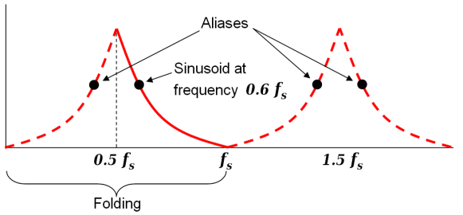

In this case for example at a sampling rate of 1 KHz if the maximum Frequency within signal is 600Hz we will obtain a Fourier Frequency component at 400 Hz because the FFT will work up to 500Hz Components.

In the Appendix of this notebook we can observe this Phenonema

Variables Related to previous codes.

Run Example 1 or Example 2 and then run FFT Code.

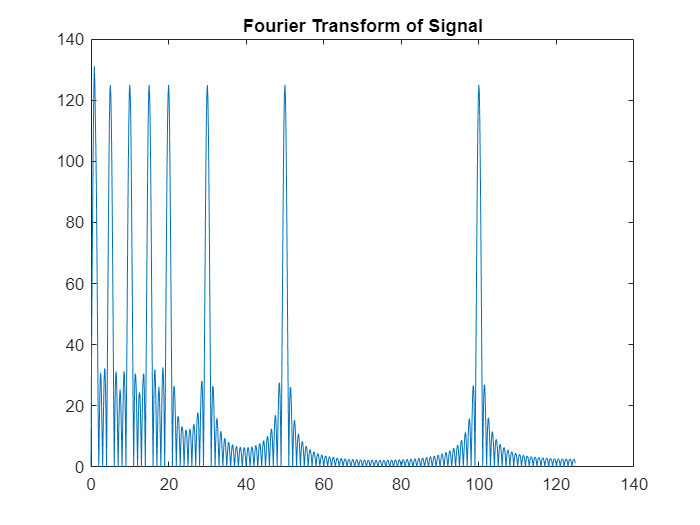

[figure not shown]

```matlab
Y = fft(signal);
L = length(signal);
Y = abs(Y);
Y = Y(1:L/2);
freqs = (0:L/2-1)*fs/L;
plot(freqs,Y)
title('Fourier Transform of Signal')
```

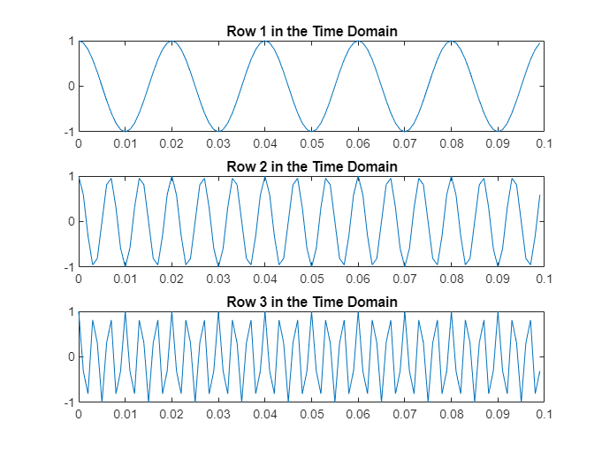

```matlab
%COSINE WAVES
clear all;
Fs = 1000;                    % Sampling frequency
T = 1/Fs;                     % Sampling period
L = 1000;                     % Length of signal
t = (0:L-1)*T;                % Time vector
x1 = cos(2*pi*50*t);          % First row wave
x2 = cos(2*pi*150*t);         % Second row wave
x3 = cos(2*pi*300*t);         % Third row wave

X = [x1; x2; x3];
for i = 1:3
    subplot(3,1,i)
    plot(t(1:100),X(i,1:100))
    title(['Row ',num2str(i),' in the Time Domain'])
end
```

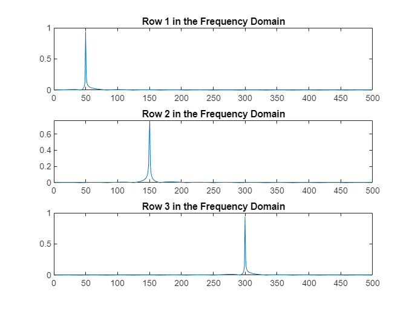

```matlab
n = 2^nextpow2(L);
dim = 2;
Y = fft(X,n,dim);
P2 = abs(Y/L);
P1 = P2(:,1:n/2+1);
P1(:,2:end-1) = 2*P1(:,2:end-1);
for i=1:3
    subplot(3,1,i)
    plot(0:(Fs/n):(Fs/2-Fs/n),P1(i,1:n/2))
    title(['Row ',num2str(i),' in the Frequency Domain'])
end
```

## Appendices

### Appendix A - Folding

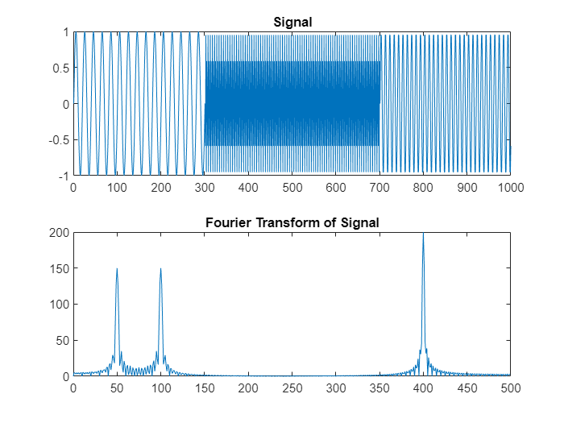

```matlab
fs = 1000; %sampling frequency
dt = 1/fs;  %DeltaT
F = [repelem(50,0.3*fs),repelem(600,0.4*fs),repelem(1100,0.3*fs)]; %Frequency Array
StopTime = length(F)/fs; %seconds
t = (0:dt:StopTime);
amp = 1;
for i= 1:length(t)-1
    signal(i) = amp*sin(2*pi*F(i)*t(i));
end;

figure()
subplot(2,1,1)
plot(signal)
title('Signal')

%FFT
Y = fft(signal);
L = length(signal);
Y = abs(Y);
Y = Y(1:L/2);
freqs = (0:L/2-1)*fs/L;
subplot(2,1,2)
plot(freqs,Y)
title('Fourier Transform of Signal')
```

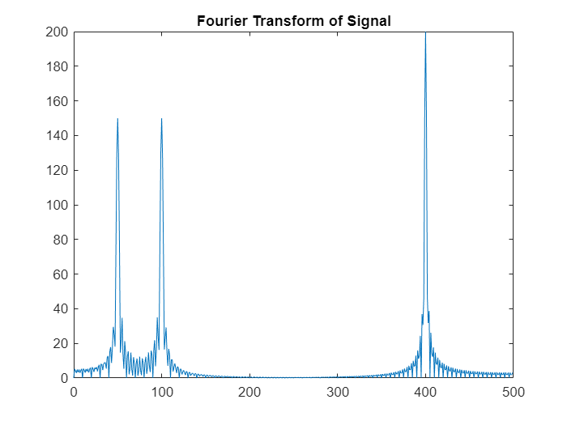

```matlab
Y = fft(signal);
L = length(signal);
Y = abs(Y);
Y = Y(1:L/2);
freqs = (0:L/2-1)*fs/L;
plot(freqs,Y)
title('Fourier Transform of Signal')
```

```matlab
Fs = 15000;
t = 0:1/Fs:1;
f = 100;
x = signal;
nfft = 10240;
X = fft(x,nfft);
X = X(1:nfft/2);
mx= abs(X);
f = (0:nfft/2-1)*Fs/nfft
```

f = 1×5120

10<sup>3</sup> ×

0 0.0015 0.0029 0.0044 0.0059 0.0073 0.0088 0.0103 0.0117 0.0132 0.0146 0.0161 0.0176 0.0190 0.0205 0.0220 0.0234 0.0249 0.0264 0.0278 0.0293 0.0308 0.0322 0.0337 0.0352 0.0366 0.0381 0.0396 0.0410 0.0425 0.0439 0.0454 0.0469 0.0483 0.0498 0.0513 0.0527 0.0542 0.0557 0.0571 0.0586 0.0601 0.0615 0.0630 0.0645 0.0659 0.0674 0.0688 0.0703 0.0718

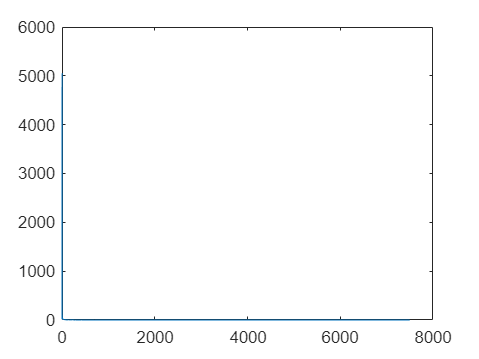

```matlab
plot(f,mx)
```